# Data Translation Project - Econometrics WQ22

Oliver Hering, Bethany Locke, Zack Carey, Jenna Maeda

3/4/2022

1. How has COVID affected the health of the retail industry, as measured by employment?
2. How has retail fared relative to other industries?
3. Retail needs to worry about who has money to spend - what has changed about who is working and earning money?

```r
library(dplyr)
library(haven)
library(tidyverse)
library(ipumsr)
library(lubridate)
library(jtools)
library(vtable)
library(fixest)
```

# Reading in the Data

```r
ddi <- read_ipums_ddi("cps_00001.xml")
data <- read_ipums_micro(ddi)
```

```
## Use of data from IPUMS CPS is subject to conditions including that users should
## cite the data appropriately. Use command `ipums_conditions()` for more details.
```

# Joining the indnames file to the data to put names to the industry codes

```r
indnames <- read.csv('indnames.csv', header = TRUE)

data <- left_join(x = data, y = indnames, by = c('IND' = 'ind'))

data <- data %>%
  relocate(indname, .after = IND)
```

# Adding a binary variable that is 0 before covid and 1 after/during covid

```r
# combining year and month into one column called 'date'
data <- data %>%
  relocate(MONTH, .after = YEAR)

data <- data %>%
  mutate(date = paste0(YEAR, '-', MONTH, '-01')) %>%
  mutate(date = ymd(date)) %>%
  relocate(date, .after = MONTH)


# creating the binary variable
data$covid <- ifelse(data$date >= '2020-03-01', 1, 0)

data <- data %>%
  relocate(covid, .after = date)


# checking to make sure its right
grouped_dates <- data %>%
  group_by(date) %>%
  summarise(mean(covid))
```

# Question 1: How has COVID affected the health of the retail industry, as measured by employment?

```r
#selecting only retail trade workers
q1data <- data %>%
  select(date, covid, EMPSTAT, indname)

q1data %>% count(EMPSTAT)
```

```
## # A tibble: 3 × 2
##                               EMPSTAT       n
##                             <int+lbl>   <int>
## 1 10 [At work]                        1998028
## 2 21 [Unemployed, experienced worker]  104653
## 3 22 [Unemployed, new worker]            4750
```

```r
#binary variable for if employed (1) or not (0).
q1data$employed <- ifelse(q1data$EMPSTAT == 10, 1, 0)

m1 <- lm(employed ~ covid, data = q1data)
export_summs(m1, digits = 3)
```

|  | Model 1 |
| --- | --- |
| (Intercept) | 0.964 *** |
|  | (0.000) |
| covid | -0.027 *** |
|  | (0.000) |
| N | 2107431 |
| R2 | 0.004 |
| *** p < 0.001; ** p < 0.01; * p < 0.05. |  |

```r
q1datatest <- q1data

q1datatest$retail_industry <- ifelse(q1datatest$indname == 'Retail Trade', 1, 0)

q1datatest[!grepl("1", q1datatest$retail_industry),]
```

```
## # A tibble: 1,889,062 × 6
##    date       covid        EMPSTAT indname              employed retail_industry
##    <date>     <dbl>      <int+lbl> <chr>                   <dbl>           <dbl>
##  1 2019-01-01     0 10 [At work]   Manufacturing               1               0
##  2 2019-01-01     0 10 [At work]   Educational Service…        1               0
##  3 2019-01-01     0 10 [At work]   Manufacturing               1               0
##  4 2019-01-01     0 10 [At work]   Educational Service…        1               0
##  5 2019-01-01     0 10 [At work]   Educational Service…        1               0
##  6 2019-01-01     0 10 [At work]   Public Administrati…        1               0
##  7 2019-01-01     0 10 [At work]   Arts, Entertainment…        1               0
##  8 2019-01-01     0 10 [At work]   Other Services, Exc…        1               0
##  9 2019-01-01     0 10 [At work]   Professional, Scien…        1               0
## 10 2019-01-01     0 21 [Unemploye… Educational Service…        0               0
## # … with 1,889,052 more rows
```

```r
q1datatest$occ <- ave(seq(nrow(q1datatest)), q1datatest$employed, q1datatest$date, q1datatest$indname, FUN = length)

q1count <- q1datatest %>%
  group_by(date, employed, covid, indname) %>%
  summarise(occ = mean(occ))
q1retailtest <- q1data %>%
  filter(indname == 'Retail Trade')

q1retailtest$occ <- ave(seq(nrow(q1retailtest)), q1retailtest$employed, q1retailtest$date, FUN = length)

q1retailtest %>%
  group_by(date, employed, covid) %>%
  summarise(occ = mean(occ))
```

```
## # A tibble: 74 × 4
## # Groups:   date, employed [74]
##    date       employed covid   occ
##    <date>        <dbl> <dbl> <dbl>
##  1 2019-01-01        0     0   307
##  2 2019-01-01        1     0  5617
##  3 2019-02-01        0     0   300
##  4 2019-02-01        1     0  5521
##  5 2019-03-01        0     0   680
##  6 2019-03-01        1     0 13485
##  7 2019-04-01        0     0   257
##  8 2019-04-01        1     0  5418
##  9 2019-05-01        0     0   258
## 10 2019-05-01        1     0  5478
## # … with 64 more rows
```

```r
m2 <- lm(employed ~ covid, data = q1retailtest)
export_summs(m2, digits = 3)
```

|  | Model 1 |
| --- | --- |
| (Intercept) | 0.956 *** |
|  | (0.001) |
| covid | -0.026 *** |
|  | (0.001) |
| N | 218369 |
| R2 | 0.003 |
| *** p < 0.001; ** p < 0.01; * p < 0.05. |  |

```r
q1retail <- q1retailtest %>%
  group_by(date, employed, covid) %>%
  summarise(occ = mean(occ))
detach("package:dplyr", unload=TRUE)
library(plyr)
q1rate <- ddply(q1count, .(date, indname), transform, rate = occ/sum(occ)) %>%
  drop_na(indname)
q1retailrate <- ddply(q1retail, .(date), transform, rate = occ/sum(occ))
detach("package:plyr", unload=TRUE)
library(dplyr)
q1rate <- filter(q1rate, employed == 1)
```

```
## No summary function supplied, defaulting to `mean_se()`
```

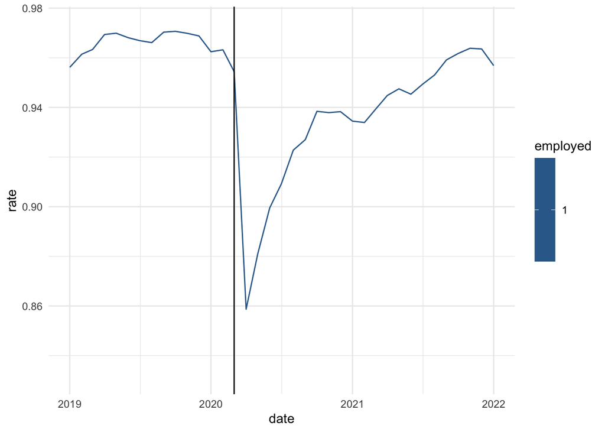

```r
ggplot(q1rate, aes(date, rate, color = employed, group = employed)) +
  stat_summary(geom = 'line') +
  geom_vline(xintercept = as.Date('2020-03-01')) +
  theme_minimal()
```

# Question 2: How has retail fared relative to other industries?

```r
#binary variable for if the industry is retail (1) or not (0)
data$retail_industry <- ifelse(data$indname == 'Retail Trade', 1, 0)

data <- data %>%
  relocate(retail_industry, .after = indname)

data$employed <- ifelse(data$EMPSTAT == 10, 1, 0)

#regular regression model
m2 <- lm(employed ~ covid*retail_industry, data = data)

#fixed effects regression model
m2feols <- feols(employed ~ covid:retail_industry | indname + date, data = data)
```

```
## NOTE: 4,750 observations removed because of NA values (RHS: 4,750, Fixed-effects: 4,750).
```

```r
export_summs(m2, m2feols, digits = 3)
```

|  | Model 1 | Model 2 |
| --- | --- | --- |
| (Intercept) | 0.968 *** |  |
|  | (0.000) |  |
| covid | -0.028 *** |  |
|  | (0.000) |  |
| retail_industry | -0.012 *** |  |
|  | (0.001) |  |
| covid:retail_industry | 0.002 * | 0.002 |
|  | (0.001) | (0.007) |
| N | 2102681 | 2102681 |
| R2 | 0.004 | 0.023 |
| *** p < 0.001; ** p < 0.01; * p < 0.05. |  |  |

```
## No summary function supplied, defaulting to `mean_se()`
```

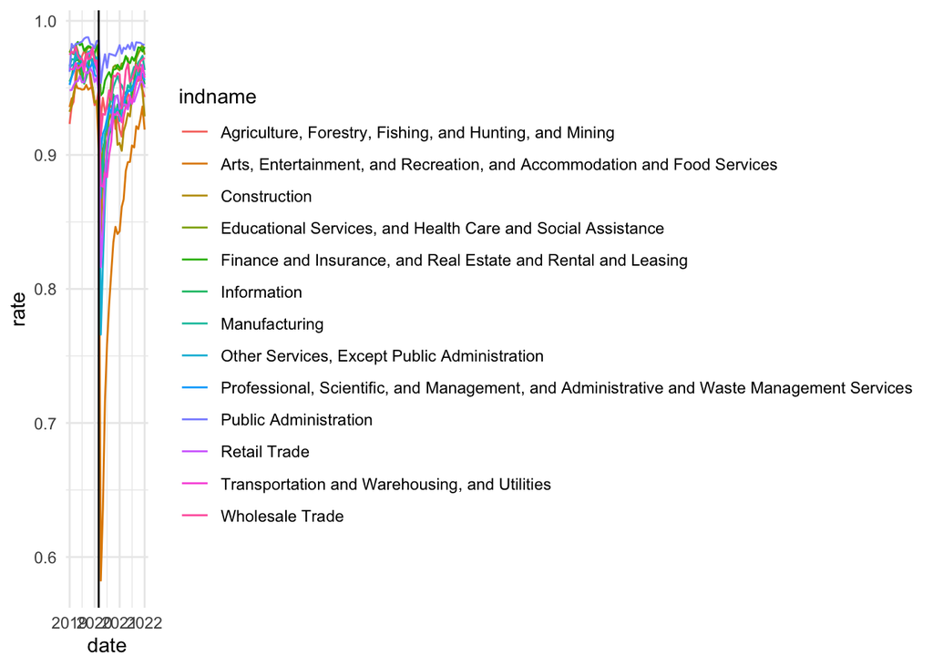

```r
ggplot(q1rate, aes(date, rate, color = indname, group = indname)) +
  stat_summary(geom = 'line') +
  geom_vline(xintercept = as.Date('2020-03-01')) +
  theme_minimal()
```

# Summary Statistics of dataset before question 3 analysis

# Age

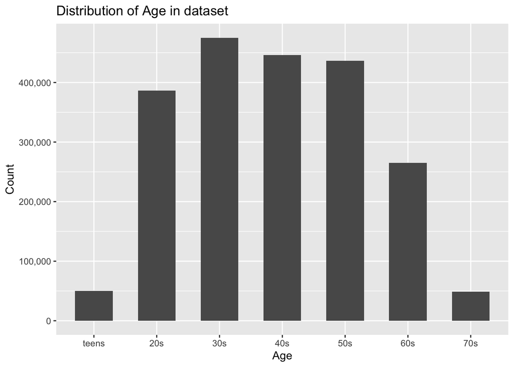

```r
# putting ages into bins
age_data <- data %>%
  mutate(age_bins = case_when(
    AGE %in% c(16:19) ~ 'teens',
    AGE %in% c(20:29) ~ '20s',
    AGE %in% c(30:39) ~ '30s',
    AGE %in% c(40:49) ~ '40s',
    AGE %in% c(50:59) ~ '50s',
    AGE %in% c(60:69) ~ '60s',
    AGE %in% c(70:79) ~ '70s'))

age_data <- age_data %>%
  relocate(age_bins, .after = AGE)

# Age distribution
age_data_summary <- age_data %>%
  count(age_bins)

age_data_summary$age_bins <- factor(age_data_summary$age_bins, levels = c('teens', '20s', '30s', '40s', '50s', '60s', '70s'))

age_barplot <- ggplot(age_data_summary, aes(x = age_bins, y = n)) +
  geom_bar(stat = 'identity', width = 0.6) +
  ggtitle('Distribution of Age in dataset') +
  labs(x = 'Age', y = 'Count')

require(scales)
age_barplot + scale_y_continuous(labels = comma)
```

# Race

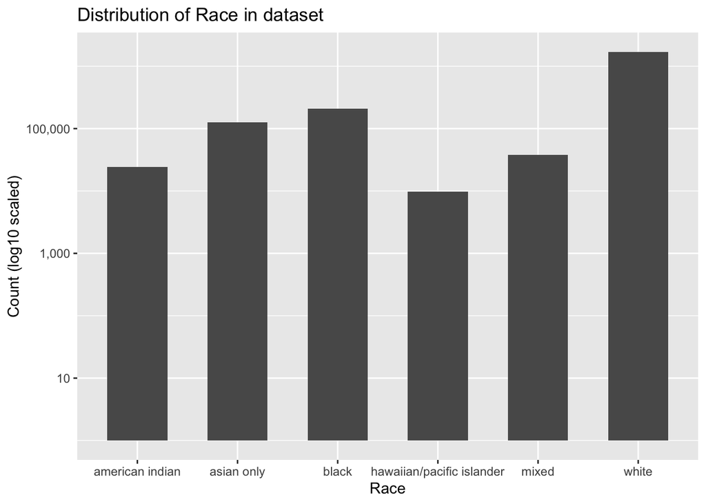

```r
# replacing race codes with text
race_data <- data %>%
  mutate(race_bins = case_when(
    RACE %in% c(100) ~ 'white',
    RACE %in% c(200) ~ 'black',
    RACE %in% c(300) ~ 'american indian',
    RACE %in% c(651) ~ 'asian only',
    RACE %in% c(652) ~ 'hawaiian/pacific islander',
    RACE %in% c(700) ~ 'other',
    RACE %in% c(801:820, 830) ~ 'mixed'))

race_data <- race_data %>%
  relocate(race_bins, .after = RACE)


# Race distribution
race_data_summary <- race_data %>%
  count(race_bins)

race_barplot <- ggplot(race_data_summary, aes(x = race_bins, y = n)) +
  geom_bar(stat = 'identity', width = 0.6) +
  xlab('Race') +
  ylab('Count (log10 scaled)') +
  ggtitle('Distribution of Race in dataset')

require(scales)
race_barplot + scale_y_continuous(labels = comma, trans = 'log10')
```

# Education

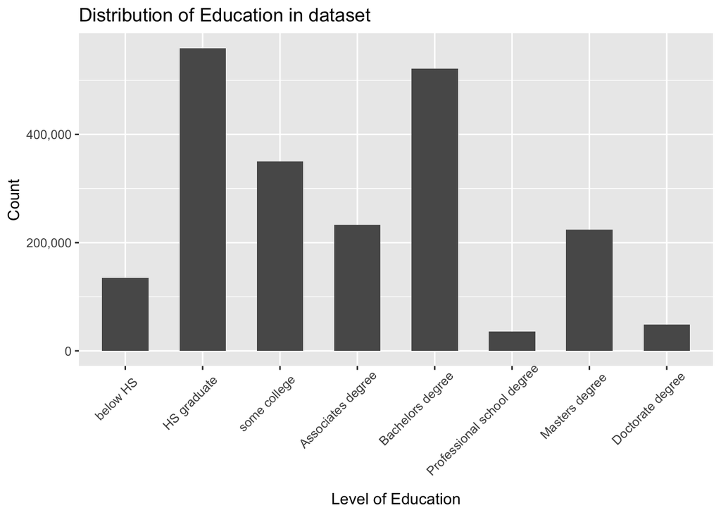

```r
# replacing Education codes with text
education_data <- data %>%
  mutate(education_bins = case_when(
    EDUC %in% c(0:72) ~ 'below HS',
    EDUC %in% c(73) ~ 'HS graduate',
    EDUC %in% c(91:92) ~ 'Associates degree',
    EDUC %in% c(80,81,90,100,110) ~ 'some college',
    EDUC %in% c(111) ~ 'Bachelors degree',
    EDUC %in% c(120:122) ~ 'Additional school No degree',
    EDUC %in% c(123) ~ 'Masters degree',
    EDUC %in% c(124) ~ 'Professional school degree',
    EDUC %in% c(125) ~ 'Doctorate degree',))


education_data <- education_data %>%
  relocate(education_bins, .after = EDUC)


# Education distribution
education_data_summary <- education_data %>%
  count(education_bins)

education_data_summary$education_bins <- factor(education_data_summary$education_bins,
                                                levels = c('below HS',
                                                           'HS graduate',
                                                           'some college',
                                                           'Associates degree',
                                                           'Bachelors degree',
                                                           'Professional school degree',
                                                           'Masters degree',
                                                           'Doctorate degree'))

education_barplot <- ggplot(education_data_summary, aes(x = education_bins, y = n)) +
  geom_bar(stat = 'identity', width = 0.6) +
  xlab('Level of Education') +
  ylab('Count') +
  ggtitle('Distribution of Education in dataset')

require(scales)
education_barplot + scale_y_continuous(labels = comma) + theme(axis.text.x = element_text(angle = 45, vjust = 0.9, hjust=0.8))
```

# Question 3: Retail needs to worry about who has money to spend - what has changed about who is working and earning money?

```r
# employed regressed on age
age_reg <- lm(employed ~ age_bins*covid, data = age_data)
export_summs(age_reg, digits = 3)
```

|  | Model 1 |
| --- | --- |
| (Intercept) | 0.946 *** |
|  | (0.001) |
| age_bins30s | 0.022 *** |
|  | (0.001) |
| age_bins40s | 0.026 *** |
|  | (0.001) |
| age_bins50s | 0.027 *** |
|  | (0.001) |
| age_bins60s | 0.026 *** |
|  | (0.001) |
| age_bins70s | 0.021 *** |
|  | (0.002) |
| age_binsteens | -0.062 *** |
|  | (0.002) |
| covid | -0.036 *** |
|  | (0.001) |
| age_bins30s:covid | 0.011 *** |
|  | (0.001) |
| age_bins40s:covid | 0.012 *** |
|  | (0.001) |
| age_bins50s:covid | 0.010 *** |
|  | (0.001) |
| age_bins60s:covid | 0.009 *** |
|  | (0.001) |
| age_bins70s:covid | 0.009 *** |
|  | (0.002) |
| age_binsteens:covid | 0.009 *** |
|  | (0.002) |
| N | 2107431 |
| R2 | 0.010 |
| *** p < 0.001; ** p < 0.01; * p < 0.05. |  |

```r
# employed regressed on race
race_reg <- feols(employed ~ i(race_bins, ref = 'white')*covid, data = race_data)
export_summs(race_reg, digits = 3)
```

|  | Model 1 |
| --- | --- |
| (Intercept) | 0.968 *** |
|  | (0.000) |
| race_bins::american indian | -0.050 *** |
|  | (0.002) |
| race_bins::asian only | 0.005 *** |
|  | (0.001) |
| race_bins::black | -0.032 *** |
|  | (0.001) |
| race_bins::hawaiian/pacific islander | -0.005 |
|  | (0.004) |
| race_bins::mixed | -0.023 *** |
|  | (0.002) |
| covid | -0.025 *** |
|  | (0.000) |
| covid:race_bins::american indian | -0.003 |
|  | (0.003) |
| covid:race_bins::asian only | -0.016 *** |
|  | (0.001) |
| covid:race_bins::black | -0.010 *** |
|  | (0.001) |
| covid:race_bins::hawaiian/pacific islander | -0.024 *** |
|  | (0.005) |
| covid:race_bins::mixed | -0.013 *** |
|  | (0.002) |
| nobs | 2107431 |
| r.squared | 0.007 |
| adj.r.squared | 0.007 |
| within.r.squared |  |
| pseudo.r.squared |  |
| sigma | 0.221 |
| nobs.1 | 2107431.000 |
| AIC | -380881.798 |
| BIC | -380731.067 |
| logLik | 190452.899 |
| *** p < 0.001; ** p < 0.01; * p < 0.05. |  |

```r
# employed regressed on education
education_reg <- feols(employed ~ i(education_bins, ref = 'HS graduate')*covid, data = education_data)
export_summs(education_reg, digits = 3)
```

|  | Model 1 |
| --- | --- |
| (Intercept) | 0.953 *** |
|  | (0.000) |
| education_bins::Associates degree | 0.019 *** |
|  | (0.001) |
| education_bins::Bachelors degree | 0.024 *** |
|  | (0.001) |
| education_bins::below HS | -0.026 *** |
|  | (0.001) |
| education_bins::Doctorate degree | 0.035 *** |
|  | (0.002) |
| education_bins::Masters degree | 0.027 *** |
|  | (0.001) |
| education_bins::Professional school degree | 0.031 *** |
|  | (0.002) |
| education_bins::some college | 0.008 *** |
|  | (0.001) |
| covid | -0.035 *** |
|  | (0.001) |
| covid:education_bins::Associates degree | 0.006 *** |
|  | (0.001) |
| covid:education_bins::Bachelors degree | 0.013 *** |
|  | (0.001) |
| covid:education_bins::below HS | -0.002 |
|  | (0.001) |
| covid:education_bins::Doctorate degree | 0.027 *** |
|  | (0.002) |
| covid:education_bins::Masters degree | 0.023 *** |
|  | (0.001) |
| covid:education_bins::Professional school degree | 0.027 *** |
|  | (0.002) |
| covid:education_bins::some college | 0.000 |
|  | (0.001) |
| nobs | 2107431 |
| r.squared | 0.012 |
| adj.r.squared | 0.012 |
| within.r.squared |  |
| pseudo.r.squared |  |
| sigma | 0.221 |
| nobs.1 | 2107431.000 |
| AIC | -390604.687 |
| BIC | -390403.711 |
| logLik | 195318.343 |
| *** p < 0.001; ** p < 0.01; * p < 0.05. |  |